# R Notebook

### UČITAVANJE PAKETA

Učitavam potrebne pakete i korisim sve 32 jezgre za zahtjevne operacije.

```r
library(data.table)
library(xts)
library(quantmod)
library(fmlr)
library(tseries)
library(data.table)
library(reticulate)
library(here)
library(future.apply)
source(here("R", "import_data.R"))
source(here("R", "features.R"))
source(here("R", "outliers.R"))
source(here("R", "parallel_functions.R"))
source(here("R", "execution.R"))
# performance
plan(multiprocess)  # for multithreading  workers = availableCores() - 8)
```

### PARAMETRI

```r
# import data
contract = 'SPY5'
upsample = FALSE
```

### UČITAVANJE PODATAKA

Svaku strategiju sam testirao sa razli;itom frekventnosti podatraka. Najčešće sam koristio minutne, 5-minutne, sate i dnevne podatke. Poneka 10-minutne ili polusatne frekvencije.

```r
# HFD
market_data <- import_mysql(
  contract = contract,
  save_path = 'D:/market_data/usa/ohlcv',
  trading_days = TRUE,
  upsample = upsample,
  RMySQL::MySQL(),
  dbname = 'odvjet12_market_data_usa',
  username = 'odvjet12_mislav',
  password = 'Theanswer0207',
  host = '91.234.46.219'
)
```

```
## [1] "Read from local file. The data is 23.59 days old."
```

```r
vix <- import_mysql(
  contract = 'VIX5',
  save_path = 'D:/market_data/usa/ohlcv',
  trading_days = TRUE,
  upsample = upsample,
  RMySQL::MySQL(),
  dbname = 'odvjet12_market_data_usa',
  username = 'odvjet12_mislav',
  password = 'Theanswer0207',
  host = '91.234.46.219'
)
```

```
## [1] "Read from local file. The data is 5.03 days old."
```

### PREPROCESSING

Predprocesne radnje za sve strategije su vrlo jednostavne. Eliminiram ourliere, prpojim VIX podatke, dodam input varijable (npr, povrate, volatilnost, kurtoyis i drugo), dodam pomaknute vrijednosti i eliminiram redove s NA vrijendosti.

```r
# Remove outliers
market_data <- remove_outlier_median(market_data, median_scaler = 25)

# merge market data and VIX
market_data <- merge(market_data, vix[, 'close'], join = 'left')
colnames(market_data)[ncol(market_data)] <- 'vix'
market_data <- na.omit(market_data)

# Add features
market_data <- add_features(market_data)

# lags
market_data$returns_lag <- data.table::shift(market_data$returns)
market_data$vix_lag <- data.table::shift(market_data$vix)

# Remove NA values
market_data <- na.omit(market_data)
```

Ideja za ovaj korak u budućnosti je korištenje wavelet transformacija.

### BACKCusum strategija

IDeja je koristiti statističke testove strukturnih lomova kako bi se identificirao lom u seriji. Zatim se poyizicije zauzimaju u trenutku pojave loma. Na primjer, ako test pokaže da je probijena gornja granica za seriju volatilnosti možemo izaći iz pozicije. Ili ako se pokaže da je kvadrat prinosa probiju gornju granicu, izlazimo iz pozicije. Ideja je da se strukturni lom na povrat ne može dugoročno održati.

```r
# backcusum roll
back_cusum_test <- function(data, col_name, window_size = 100, side = c('greter', 'less')) {
  bc <- slider_parallel(
    .x = as.data.table(data),
    .f =   ~ {
      formula_ <- paste0('.$', col_name, ' ~ 1')
      backCUSUM::SBQ.test(stats::as.formula(formula_), alternative = side)[['statistic']]
    },
    .before = window_size - 1,
    .after = 0L,
    .complete = TRUE,
    n_cores = -1
  )
  bc <- unlist(bc)
  bc <- c(rep(NA, window_size - 1), bc)
  return(bc)
}
market_data$bc_standardized_returns_less <- back_cusum_test(market_data, 'standardized_returns', 80, side = 'less')
```

```
## [1] "Number of subsamples (max used cores): 3636"
## [1] "The fucntion took -8.29786111911138"
```

```r
market_data$bc_standardized_returns_greater <- back_cusum_test(market_data, 'standardized_returns', 80, side = 'greater')
```

```
## [1] "Number of subsamples (max used cores): 3636"
## [1] "The fucntion took -8.21531678040822"
```

```r
market_data$bc_std_80 <- back_cusum_test(market_data, 'std_80', 100, side = 'greater')
```

```
## [1] "Number of subsamples (max used cores): 2909"
## [1] "The fucntion took -11.2335871855418"
```

```r
market_data <- na.omit(market_data)

# Log statistics
quantile(market_data$bc_standardized_returns_less, seq(0, 1, 0.05), na.rm = TRUE)
```

```
##        0%        5%       10%       15%       20%       25%       30%       35%
## 0.0000000 0.4173454 0.4689640 0.5069603 0.5402440 0.5705825 0.5989566 0.6266370
##       40%       45%       50%       55%       60%       65%       70%       75%
## 0.6535952 0.6803909 0.7076940 0.7361638 0.7657452 0.7969084 0.8305070 0.8682020
##       80%       85%       90%       95%      100%
## 0.9106320 0.9612380 1.0288088 1.1342996 2.5785360
```

```r
quantile(market_data$bc_standardized_returns_greater, seq(0, 1, 0.05), na.rm = TRUE)
```

```
##        0%        5%       10%       15%       20%       25%       30%       35%
## 0.0007880 0.4136830 0.4637324 0.5021810 0.5347630 0.5649640 0.5932172 0.6200640
##       40%       45%       50%       55%       60%       65%       70%       75%
## 0.6459442 0.6717050 0.6978690 0.7251951 0.7536350 0.7843921 0.8175020 0.8542405
##       80%       85%       90%       95%      100%
## 0.8980444 0.9504959 1.0185738 1.1267536 2.5161530
```

```r
quantile(market_data$bc_std, seq(0, 1, 0.05))
```

```
##         0%         5%        10%        15%        20%        25%        30%
##  0.0000000  0.0087791  0.0459366  0.1112290  0.2117198  0.3467640  0.5485544
##        35%        40%        45%        50%        55%        60%        65%
##  0.8124505  1.1494248  1.5500501  1.9876170  2.4450426  2.9051734  3.3269244
##        70%        75%        80%        85%        90%        95%       100%
##  3.7182948  4.0893315  4.4385964  4.7915899  5.1944096  5.7881598 13.3447490
```

Za procjenu strukturnog loma sam koristio metodu iz novog rada (2020), BackCUSUM test. Koraci strategije us dakle jednostavni:

```r
# Backtest
Rcpp::cppFunction('NumericVector create_signs_test(NumericVector x, float cv) {
    int n = x.size();
    NumericVector sign(n);

    for(int i = 1; i < n; ++i) {
      if (i == 1) sign[i] = R_NaN;
      else if(x[i - 1] > cv) sign[i] = 0;
      else sign[i] = 1;
    }
    return sign;
}')

backtest <- function(df, greater, cv) {
  df$side <- create_signs_test(greater, cv)
  df$returns_strategy <- df$returns * df$side
  results_xts <- df[, c('returns', 'returns_strategy')]
  results_xts <- na.omit(results_xts)
  p <- charts.PerformanceSummary(results_xts, plot.engine = 'ggplot2')
  return(list(returns = results_xts, plot = p))
}

# test
backcusum_mean <- TTR::SMA(market_data$bc_standardized_returns_greater, 150)
quantile(backcusum_mean, seq(0, 1, 0.05), na.rm = TRUE)
```

```
##        0%        5%       10%       15%       20%       25%       30%       35%
## 0.4449233 0.5871004 0.6138449 0.6316722 0.6466922 0.6599962 0.6724006 0.6842138
##       40%       45%       50%       55%       60%       65%       70%       75%
## 0.6960479 0.7074129 0.7183658 0.7300696 0.7415543 0.7537418 0.7666038 0.7809142
##       80%       85%       90%       95%      100%
## 0.7979917 0.8168691 0.8420738 0.8826841 1.1691551
```

[figure not shown]

```r
result_plot <- backtest(market_data, backcusum_mean, 0.8)
```

```r
result_plot$plot
```

### DYNAMIC PROGRAMING SEGMENTS (DPSEG) STRATEGIJA

```r
dpseg_roll <- function(data, window_size = 100) {
  DT <- as.data.table(market_data)[, .(time = index, price = close)][, time := as.numeric(time)]
  dpseg_last <- slider_parallel(
    .x = DT,
    .f =   ~ {
      library(dpseg)
      segs <- dpseg(.x$time, .x$price, jumps=FALSE, store.matrix=TRUE, verb=FALSE, P = 0.1)
      slope_last <- segs$segments$slope[length(segs$segments$slope)]
      slope_last
    },
    .before = window_size - 1,
    .after = 0L,
    .complete = TRUE,
    n_cores = -1
  )
  dpseg_last <- unlist(dpseg_last)
  dpseg_last <- c(rep(NA, window_size - 1), dpseg_last)
  return(dpseg_last)
}
results_dpseg <- dpseg_roll(market_data, 400)
```

```
## [1] "Number of subsamples (max used cores): 727"
## [1] "The fucntion took -2.72745581467946"
```

```r
quantile(results_dpseg, seq(0, 1, .05), na.rm = TRUE)
```

```
##            0%            5%           10%           15%           20%
## -8.350000e-03 -3.266131e-05 -1.449559e-05 -8.274317e-06 -5.365235e-06
##           25%           30%           35%           40%           45%
## -3.313910e-06 -2.054455e-06 -1.005735e-06 -2.100951e-07  5.209029e-07
##           50%           55%           60%           65%           70%
##  1.190215e-06  1.879120e-06  2.576595e-06  3.368113e-06  4.364113e-06
##           75%           80%           85%           90%           95%
##  5.741857e-06  7.902906e-06  1.154031e-05  1.785290e-05  3.806062e-05
##          100%
##  1.505000e-02
```

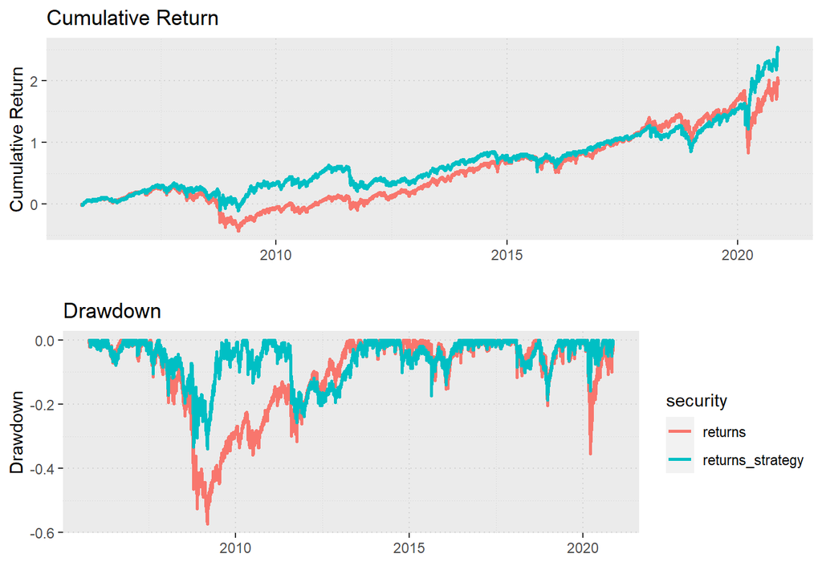

```r
results_2 <- cbind(market_data, slope = results_dpseg)
results_2$sign <- ifelse(results_2$slope > 0.000005, 0L, 1)
results_2$sign <- shift(results_2$sign, 1L, type = 'lag')
results_2$returns_strategy <- results_2$returns * results_2$sign
PerformanceAnalytics::charts.PerformanceSummary(results_2[, c('returns', "returns_strategy")], plot.engine = 'ggplot2')
```

Provjeravao sam osjetljivost strategije na različite parametre, ali neij se pokazala uspješnom.

### STRATEGIJA VARIJACIJE KOEFICIJENATA

Keficijenti nisu statični kroz vrijeme nego se mijenjaju. Na primjer, korelacija prethodnog i sadašnjeg bara može biti 0.7 u prosjeku, ali u pojedinim periodima može biti 0.3 ili 1.1. Ideja strategije je pratiti vrijendost koeficijenta na određenoj duljini prozora i utvrditi smjer trgoanja kada koeficijent naraste ili padne iznad neke kritične vrijednosti.

```r
roll_model <- function(data, window_size = 100) {
  coefficient <- slider_parallel(
    .x = as.data.table(data),
    .f =   ~ {
      x <- arima(.x$vix, order = c(2L, 0L, 1L), method="CSS")
      # $coefficients[2]
      x$coef[1]
    },
    .before = window_size - 1,
    .after = 0L,
    .complete = TRUE,
    n_cores = -1
  )
  coefficient <- unlist(coefficient)
  coefficient <- c(rep(NA, window_size-1), coefficient)
}
results_varcoeff <- roll_model(market_data, 254)
```

```
## [1] "Number of subsamples (max used cores): 1145"
```

[output not shown]

[output cut: 47215 more lines]

[output not shown]

```
## [1] "The fucntion took -3.56186728477478"
```

```r
# df table
df <- cbind(market_data, coefs = results_varcoeff)
df$coefs_mean <- roll_mean(df$coefs, 256)
#plot(df$coefs_mean, type = 'l')
df <- na.omit(df)

# sides!
side <- vector('integer', nrow(df))
coefs <- df$coefs_mean
label <- ifelse(market_data$returns > 0, 1, -1)
for (i in 1:nrow(df)) {
 if (i %in% c(1, 2)) {
   side[i] <- NA
 } else if (coefs[i-1] > 1) {
   side[i] <- -1
 } else {
   side[i] <- 1
 }
}
side <- ifelse(side == -1, 0, 1)
sum(side == 0, na.rm = TRUE) / length(side)  # TRADE FREQ
```

```
## [1] 0.2384449
```

```r
nrow(df) * (sum(side == 0, na.rm = TRUE) / length(side))  # Number of trades
```

```
## [1] 69227
```

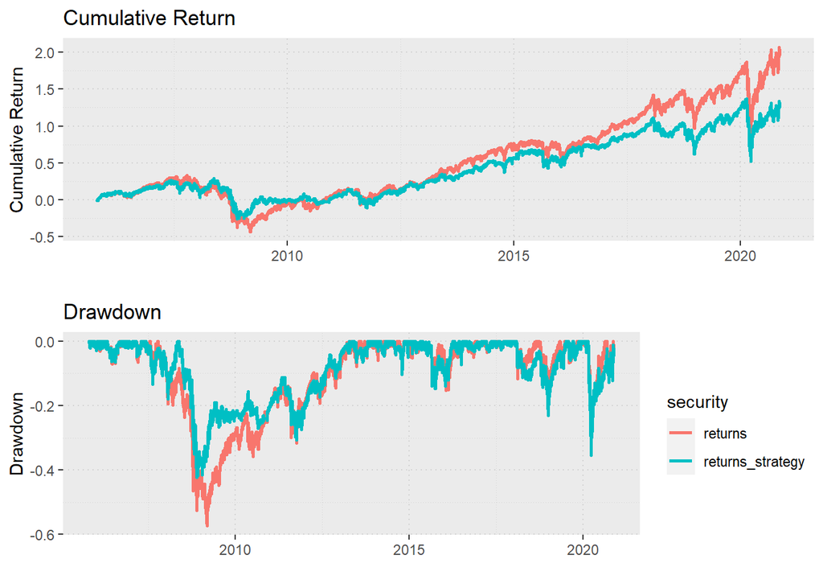

```r
df$returns_strategy <- df$returns * side
perf <- xts::xts(df[, c('returns', 'returns_strategy')])
PerformanceAnalytics::charts.PerformanceSummary(perf, plot.engine = 'ggplot2')
```

### DRUGE STRATEGIJE

Dodatne strategije: - Exuber u R-u - Jednostavni momentum - kupi ako je raslo u prethodnih n raydoblja. - Jednostavna VIX strategija - kupi ako je VIX iznad određene vrijednosti.

### IDEJE

Razvoj strategija za manje institucionalne ulagače ili sofisticirane investitore.

Razvoj stetagija koje se temelj na faktor investiranju

Uključiti opcije. Na primjer kupiti put opciju ako vrijednost VIX-a naraste.

Koristiti tekstualne podatkeČ preplata na određeni datafeed.